# Suavizamiento Exponencial y Medias Móviles

Trabajo 1. Análisis de Series de Tiempo

Bladimir Valerio Morales Torrez

Octubre 2021

# 1 Introducción

Para este primer trabajo de análisis de series de tiempo se aplicarán técnicas de modelamiento en series temporales, como las medias móviles con diferente orden y los métodos de suavizamiento exponencial simple, doble y triple o también conocidos como modelos de Holt, Holt dos parámetros y Holt-Winters respectivamente.

Las series de tiempo a aplicarse son:

- Indicador de inflación de Bolivia (enero 2014 a septiembre 2021).
- Gasto en la exportación de bienes y servicios del producto interno bruto a precios constantes (1980 a 2020).
- Indice de consumo de agua potable ICAP (enero 1990 a julio 2021).

Se puede encontrar el repositorio de datos y del informe en el siguiente enlace (https://github.com/bladimir-morales/series_de_tiempo).

Se puede visualizar el presente informe en formato pdf, en el siguiente enlace:

- https://bladimir-morales.github.io/series_de_tiempo/trabajo1.pdf

Se puede visualizar el presente informe en formato html, en el siguiente enlace:

- https://bladimir-morales.github.io/series_de_tiempo/trabajo1.html

# 2 Indicador de Inflación de Bolivia

## 2.1 Descripción

### 2.1.1 Datos

La inflación, en economía, es el aumento generalizado y sostenido de los precios de los bienes y servicios existentes en el mercado durante un período de tiempo, generalmente un año. Cuando el nivel general de precios sube, con cada unidad de moneda se adquieren menos bienes y servicios. Es decir, que la inflación refleja la disminución del poder adquisitivo de la moneda: una pérdida del valor real del medio interno de intercambio y unidad de medida de una economía. Una medida frecuente de la inflación es el índice de precios, que corresponde al porcentaje anualizado de la variación general de precios en el tiempo (el más común es el índice de precios al consumidor IPC[^1].

### 2.1.2 Periodo de estudio

La serie de tiempo esta con periodicidad mensual, comprendidos desde enero de 2014 hasta septiembre de 2021, teniendo en total 93 observaciones.

### 2.1.3 Fuente de datos

La información del indicador de la inflacion de Bolivia se puede encontrar en la página oficial del Banco Central de Bolivia (BCB) [^2], sección de “Información económica” y subsección “Inidcadores de Inflación”. Específicamente se puede observar los datos en formato establecido por la institución del siguiente enlace: (https://www.bcb.gob.bo/?q=indicadores_inflacion).

Para fines prácticos se puso la variable en estudio en formato *.txt, el cual puede ser descargado del siguiente enlace (https://github.com/bladimir-morales/series_de_tiempo/blob/main/data/inflacion.txt).

## 2.2 Gráfico

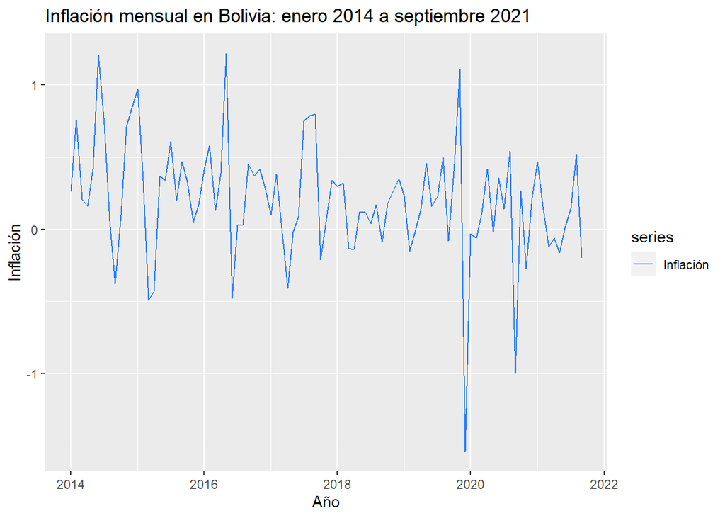

```r
url<-"https://raw.githubusercontent.com/bladimir-morales/series_de_tiempo/main/data/inflacion.txt"
inflacion<-read.table(url,head=T)
inflacion_serie<-ts(inflacion$inflacion,start = c(2014,1),frequency = 12)

autoplot(inflacion_serie,series = "Inflación")+
  ggtitle("Inflación mensual en Bolivia: enero 2014 a septiembre 2021")+
  xlab("Año")+ylab("Inflación")+
  scale_color_manual(values="#2B7DFF")
```

En el gráfico visualmente se puede observar que la serie de tiempo en estudio podría tener algún tipo de tendencia y al parecer no presenta estacionalidad. Pero para determinar de mejor forma estos efectos se hará un análisis de gráficos de tendencia y estacionalidad.

### 2.2.1 Tendencia

Para obtener la tendencia de la serie de tiempo, se aplicará una media móvil de orden 12 ya que las observaciones son mensuales.

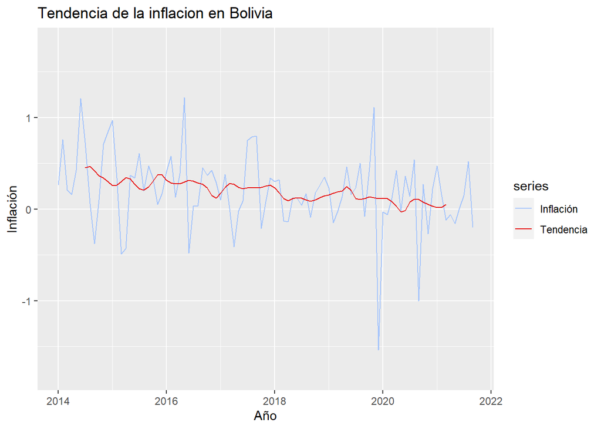

```r
ma_inflacion_serie<-ma(inflacion_serie,order = 12)

autoplot(inflacion_serie,series = "Inflación")+
  autolayer(ma_inflacion_serie,series="Tendencia")+
  ggtitle("Tendencia de la inflacion en Bolivia")+
  xlab("Año")+ylab("Inflación")+
  ylim(-1.8,1.8)+
  scale_color_manual(values=c("#A4C4FC","#E80808"))
```

Con la media móvil de orden 12 se puede observar en el gráfico que posiblemente tenga una tendencia decreciente, cabe mencionar que son datos muy cercanos a cero, y en su gran parte estarían variando entre $-1$ a $1$, por tal motivo se tendria que tener bastante cuidado en asumir tendencia decreciente.

### 2.2.2 Estacionalidad

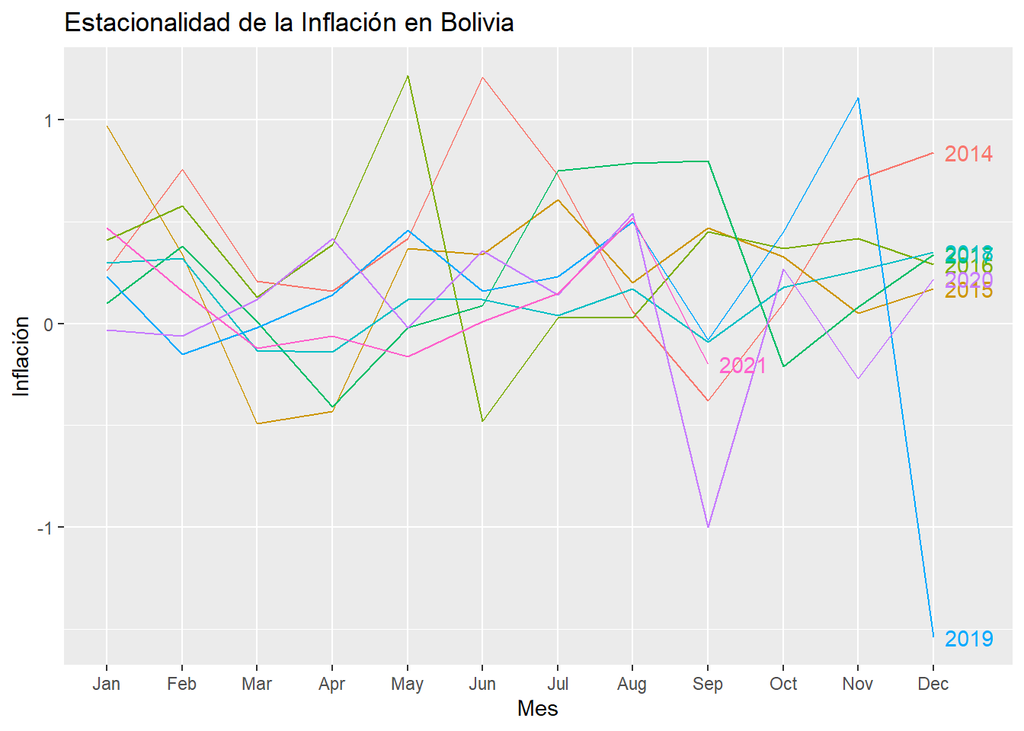

```r
ggseasonplot(inflacion_serie,main="Estacionalidad de la Inflación en Bolivia",
           year.labels = T,xlab="Mes",ylab="Inflación")
```

En este gráfico se puede observar que existe los datos están alrededor de cero con poca variabilidad, es importante mencionar que en diciembre del 2019 se producio una inflación negativa significativa a comparación de los otros meses, por otro lado no se observa un comportamiento estacional.

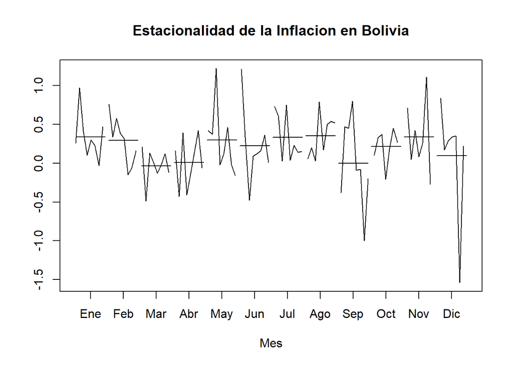

```r
monthplot(inflacion_serie,ylab="",main="Estacionalidad de la Inflacion en Bolivia",
          labels = c("Ene","Feb","Mar","Abr","May","Jun","Jul","Ago","Sep","Oct","Nov","Dic"),
          xlab="Mes")
```

En este último gráfico se puede observar que podría existir un efecto estacional ya que en cada uno de los meses existe bastante variabilidad.

## 2.3 Datos de entrenamiento y test

Para efecto de obtener un modelo óptimo y lo más preciso posible, se dividirá la serie de tiempo en dos conjuntos:

- Conjunto de datos de entrenamiento:

Se tomará en cuenta los datos desde enero de 2014 hasta diciembre de 2020, contando con 84 observaciones.

- Conjunto de datos de test.

Se tomará en cuenta los datos desde enero de 2021 hasta septiembre de 2021, contando con 9 observaciones.

En el siguiente gráfico se puede observar la serie de entrenamiento y de test.

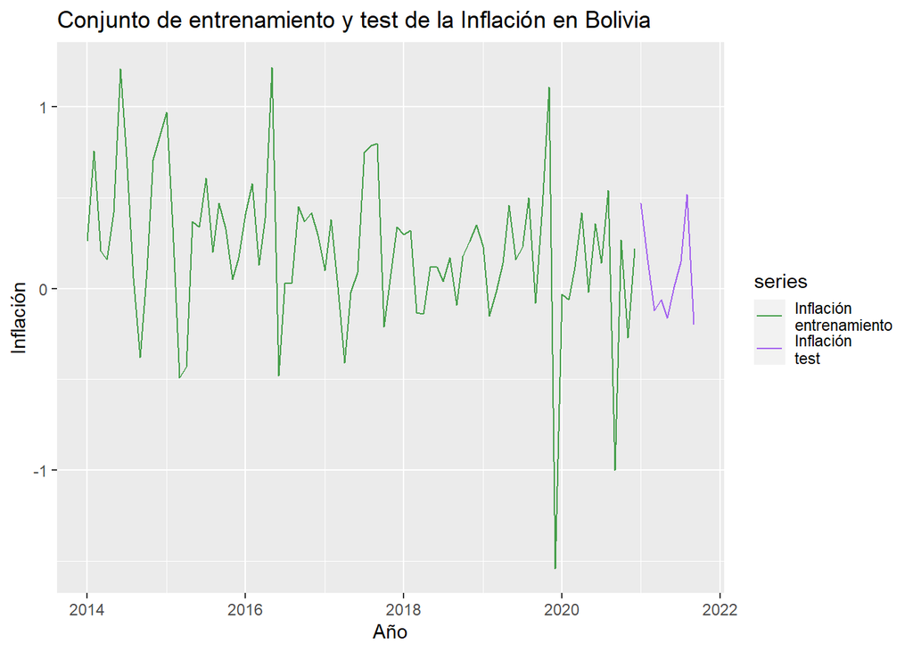

```r
inflacion_serie_ent<-ts(inflacion$inflacion,start = c(2014,1),end = c(2020,12), frequency=12)
inflacion_serie_test<-ts(inflacion$inflacion[85:93],start = c(2021,1), frequency=12)

autoplot(inflacion_serie_ent,series = "Inflación \nentrenamiento")+
  autolayer(inflacion_serie_test,series="Inflación \ntest")+
  ggtitle("Conjunto de entrenamiento y test de la Inflación en Bolivia")+
  xlab("Año")+ylab("Inflación")+
  scale_color_manual(values=c("#469F4B","#A462EF"))
```

## 2.4 Estimación

Se estimaran dos modelos posibles para el conjunto de datos de entrenamiento, tomando en cuenta que nuestra serie de tiempo como se pudo observar posiblemente tiene tendencia y estacionalidad.

### 2.4.1 Modelo 1

Para este primer modelo, se estimarán los datos con el método de Holt o también llamado suavizamiento exponencial simple, donde se descartaria que la serie tenga tendencia y estacionalidad.

La estimación se hará estimando un parámetros de suavizamiento $\alpha$. El software R cuenta con la función $HoltWinters()$ que encuentra los valores óptimos de los parámetros, en este caso para el $\alpha$.

```r
mod1_inflacion_serie_ent<-HoltWinters(inflacion_serie_ent,beta=F,gamma = F)
mod1_inflacion_serie_ent
```

```
## Holt-Winters exponential smoothing without trend and without seasonal component.
##
## Call:
## HoltWinters(x = inflacion_serie_ent, beta = F, gamma = F)
##
## Smoothing parameters:
##  alpha: 0.03026668
##  beta : FALSE
##  gamma: FALSE
##
## Coefficients:
##        [,1]
## a 0.1518322
```

### 2.4.2 Modelo 2

Para este segundo modelo, se estimarán los datos con el método de Holt-Winters o también llamado suavizamiento exponencial triple, esto debido a que la serie de tiempo posiblemente cuente con tendencia decreciente y estacionalidad.

La estimación se hará estimando tres parámetros de suavizamiento $\alpha$, $\beta$ y $\gamma$. El software R cuenta con la función $HoltWinters()$ que encuentra los valores óptimos de los parámetros, en este caso para el $\alpha$, $\beta$ y $\gamma$.

```r
mod2_inflacion_serie_ent<-HoltWinters(inflacion_serie_ent)
mod2_inflacion_serie_ent
```

```
## Holt-Winters exponential smoothing with trend and additive seasonal component.
##
## Call:
## HoltWinters(x = inflacion_serie_ent)
##
## Smoothing parameters:
##  alpha: 0.005615494
##  beta : 1
##  gamma: 0.4178776
##
## Coefficients:
##             [,1]
## a    0.015787905
## b   -0.006947634
## s1   0.094012392
## s2  -0.013914836
## s3  -0.076123161
## s4   0.068627329
## s5   0.127996918
## s6   0.142986255
## s7   0.153339165
## s8   0.370626593
## s9  -0.434416421
## s10  0.195575128
## s11  0.188304865
## s12 -0.209410718
```

## 2.5 MSE y MAPE

Se calculará el cuadrado medio del error MSE y el Porcentaje de error absoluto medio MAPE, para ambos modelos.

### 2.5.1 Cuadrado Medio del Error MSE

**Modelo 1. Modelo Holt (suavizamiento exponencial simple)**

```r
mse1<-mod1_inflacion_serie_ent$SSE/length(mod1_inflacion_serie_ent$x)
mse1
```

```
## [1] 0.1783495
```

Para el modelo de Holt el cuadrado medio del error MSE es igual a 0.1783495

**Modelo 2. Modelo Holt-Winters (suavizamiento exponencial triple)**

```r
mse2<-mod2_inflacion_serie_ent$SSE/length(mod2_inflacion_serie_ent$x)
mse2
```

```
## [1] 0.211466
```

Para el modelo de Holt-Winters el cuadrado medio del error MSE es igual a 0.211466

### 2.5.2 Porcentaje de error absoluto medio MAPE

**Modelo 1. Modelo Holt (suavizamiento exponencial simple)**

```r
mape1<-mape(mod1_inflacion_serie_ent$x,mod1_inflacion_serie_ent$fitted[,1])
mape1
```

```
## [1] 205.9801
```

Para el modelo de Holt el porcentaje de error absoluto MAPE es igual a 205.9800841

**Modelo 2. Modelo Holt-Winters (suavizamiento exponencial triple)**

```r
mape2<-mape(mod2_inflacion_serie_ent$x,mod2_inflacion_serie_ent$fitted[,1])
mape2
```

```
## [1] 277.2953
```

Para el modelo de Holt-Winters el porcentaje de error absoluto MAPE es igual a 277.2953143

### 2.5.3 Decisión de modelo apropiado

Como se pudo observar el MSE y el MAPE del modelo Holt es menor al del modelo de Holt-Winters, por tal motivo se decide modelar la serie de tiempo con el modelo de suavizamiento exponencial simple.

## 2.6 Gráfico de la serie observada y ajustada

Para el siguiente gráfico se utilizará el modelo de Holt para ajustar la serie de tiempo del conjunto de entrenamiento.

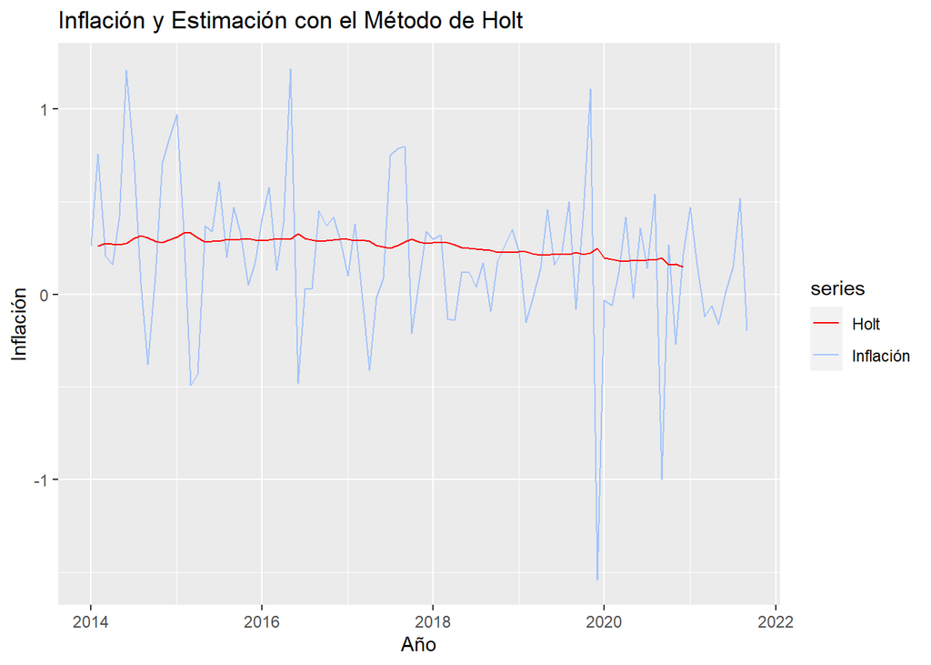

```r
autoplot(inflacion_serie,series = "Inflación")+
  autolayer(mod1_inflacion_serie_ent$fitted[,1],series="Holt")+
  ggtitle("Inflación y Estimación con el Método de Holt")+
  xlab("Año")+ylab("Inflación")+
  scale_color_manual(values=c("#FF0000","#A4C4FC"))
```

## 2.7 Predicción para datos de test

Con el modelo de Holt se predicirá los 9 datos restantes del conjunto de test a partir de los datos de entrenamiento. Con el software R se halla estos con sus respectivos intervalos.

```r
pred_mod1_inflacion_serie_ent<-forecast(mod1_inflacion_serie_ent,9)
summary(pred_mod1_inflacion_serie_ent)
```

```
##
## Forecast method: HoltWinters
##
## Model Information:
## Holt-Winters exponential smoothing without trend and without seasonal component.
##
## Call:
## HoltWinters(x = inflacion_serie_ent, beta = F, gamma = F)
##
## Smoothing parameters:
##  alpha: 0.03026668
##  beta : FALSE
##  gamma: FALSE
##
## Coefficients:
##        [,1]
## a 0.1518322
##
## Error measures:
##                       ME      RMSE       MAE      MPE     MAPE      MASE
## Training set -0.04305813 0.4248509 0.2994522 22.21193 208.4618 0.6829446
##                    ACF1
## Training set 0.02574829
##
## Forecasts:
##          Point Forecast      Lo 80     Hi 80      Lo 95     Hi 95
## Jan 2021      0.1518322 -0.3931255 0.6967899 -0.6816087 0.9852731
## Feb 2021      0.1518322 -0.3933751 0.6970394 -0.6819903 0.9856547
## Mar 2021      0.1518322 -0.3936245 0.6972889 -0.6823718 0.9860362
## Apr 2021      0.1518322 -0.3938738 0.6975382 -0.6827531 0.9864175
## May 2021      0.1518322 -0.3941230 0.6977874 -0.6831343 0.9867987
## Jun 2021      0.1518322 -0.3943721 0.6980365 -0.6835152 0.9871796
## Jul 2021      0.1518322 -0.3946211 0.6982855 -0.6838960 0.9875604
## Aug 2021      0.1518322 -0.3948700 0.6985344 -0.6842766 0.9879410
## Sep 2021      0.1518322 -0.3951187 0.6987831 -0.6846571 0.9883215
```

En el siguiente gráfico se puede observar de mejor manera los datos de predicción del conjunto de test, el conjunto de entrenamiento y el conjunto de test de la serie de tiempo en estudio.

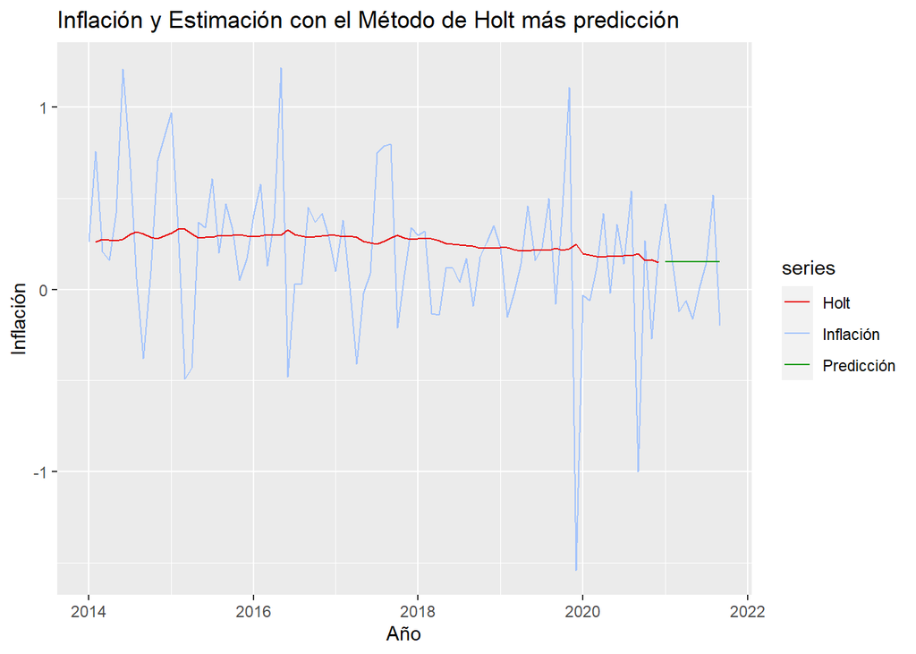

```r
autoplot(inflacion_serie,series = "Inflación")+
  autolayer(mod1_inflacion_serie_ent$fitted[,1],series="Holt")+
  autolayer(pred_mod1_inflacion_serie_ent$mean,series="Predicción")+
  ggtitle("Inflación y Estimación con el Método de Holt más predicción")+
  xlab("Año")+ylab("Inflación")+
  scale_color_manual(values=c("#E80808","#A4C4FC","#189B0D"))
```

## 2.8 MAPE para datos de test

Ahora se hallará el porcentaje de error absoluto medio MAPE de los datos de test con los datos de predicción a partir del modelo de Holt.

```r
mape_test<-mape(inflacion_serie_test,pred_mod1_inflacion_serie_ent$mean)
mape_test
```

```
## [1] 279.2819
```

El MAPE para el conjunto de test es igual a 279.2818628, se puede ver que es mayor al MAPE del conjunto de entrenamiento (205.9800841). Esto puede ser respuesta a que los pocos datos que se están calculando.

## 2.9 Predicción final

Finalmente se considerará todas las observaciones de la serie de tiempo de la inflación en Bolivia, para poder predecir 5 meses adelante, vale decir del mes de octubre del 2021 a febrero del 2022.

```r
modfin_inflacion_serie<-HoltWinters(inflacion_serie,beta = F,gamma = F)
modfin_inflacion_serie
```

```
## Holt-Winters exponential smoothing without trend and without seasonal component.
##
## Call:
## HoltWinters(x = inflacion_serie, beta = F, gamma = F)
##
## Smoothing parameters:
##  alpha: 0.03444185
##  beta : FALSE
##  gamma: FALSE
##
## Coefficients:
##        [,1]
## a 0.1252133
```

```r
pred_modfin_inflacion_serie<-forecast(modfin_inflacion_serie,5)
```

También se puede obtener con el softare R un resumen del modelo aplicado en este caso Holt.

```r
summary(pred_modfin_inflacion_serie)
```

```
##
## Forecast method: HoltWinters
##
## Model Information:
## Holt-Winters exponential smoothing without trend and without seasonal component.
##
## Call:
## HoltWinters(x = inflacion_serie, beta = F, gamma = F)
##
## Smoothing parameters:
##  alpha: 0.03444185
##  beta : FALSE
##  gamma: FALSE
##
## Coefficients:
##        [,1]
## a 0.1252133
##
## Error measures:
##                       ME      RMSE       MAE      MPE     MAPE      MASE
## Training set -0.04253757 0.4115384 0.2915693 17.86554 211.1839 0.6879438
##                   ACF1
## Training set 0.0246835
##
## Forecasts:
##          Point Forecast      Lo 80     Hi 80      Lo 95     Hi 95
## Oct 2021      0.1252133 -0.4022438 0.6526705 -0.6814628 0.9318894
## Nov 2021      0.1252133 -0.4025566 0.6529832 -0.6819411 0.9323677
## Dec 2021      0.1252133 -0.4028692 0.6532958 -0.6824191 0.9328458
## Jan 2022      0.1252133 -0.4031815 0.6536082 -0.6828969 0.9333235
## Feb 2022      0.1252133 -0.4034937 0.6539204 -0.6833744 0.9338010
```

Se puede observar que el MAPE bajo el modelo de Holt de todas las observaciones es mayor que el MAPE de los datos de entrenamiento con una diferencia de $5.2038$ puntos porcentuales.

Por lo tanto se esperaría que para el mes de octubre del 2021 se tenga una inflación en Bolivia de $0.1252133$.

Para efectos visuales se presenta en el siguiente gráfico la serie original, la serie ajustada con el modelo de Holt y las predicciones con sus respectivos intervalos.

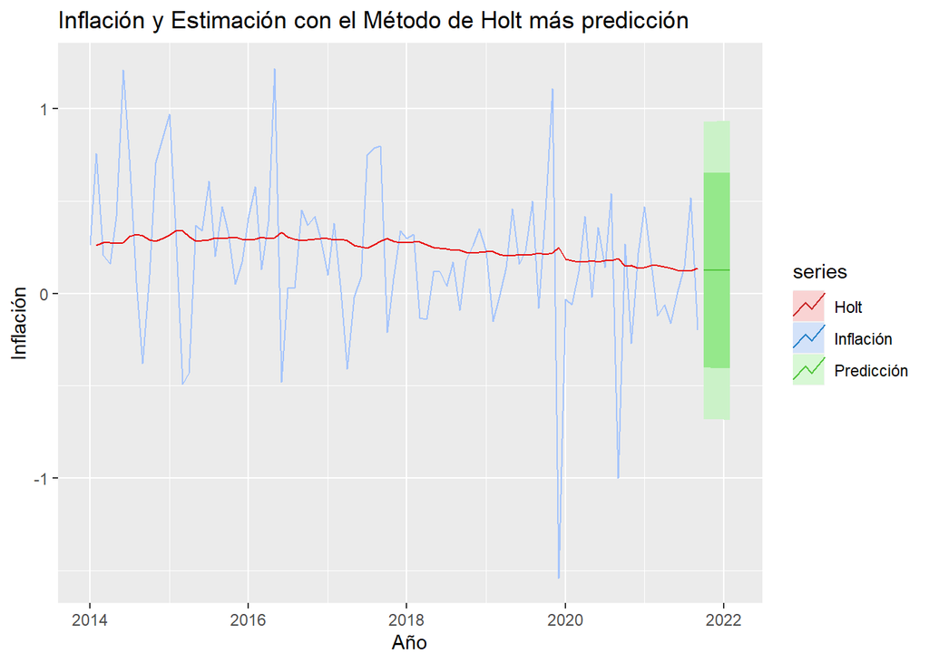

```r
autoplot(inflacion_serie,series = "Inflación")+
  autolayer(modfin_inflacion_serie$fitted[,1],series="Holt")+
  autolayer(pred_modfin_inflacion_serie,series="Predicción")+
  ggtitle("Inflación y Estimación con el Método de Holt más predicción")+
  xlab("Año")+ylab("Inflación")+
  scale_color_manual(values=c("#E80808","#A4C4FC","#189B0D"))
```

Para visualizar de mejor manera la predicción se tomará en cuenta los datos desde el año 2020.

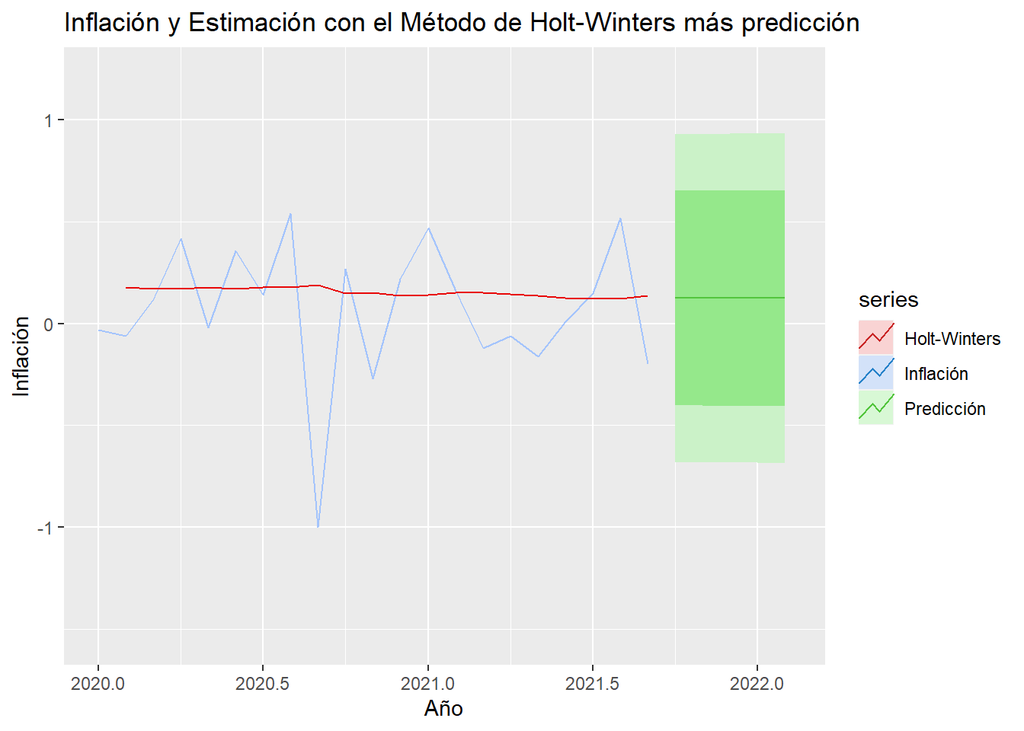

```r
autoplot(inflacion_serie,series = "Inflación")+
  autolayer(modfin_inflacion_serie$fitted[,1],series="Holt-Winters")+
  autolayer(pred_modfin_inflacion_serie,series="Predicción")+
  ggtitle("Inflación y Estimación con el Método de Holt-Winters más predicción")+
  xlab("Año")+ylab("Inflación")+
  xlim(2020,2022.1)+
  scale_color_manual(values=c("#E80808","#A4C4FC","#189B0D"))
```

## 2.10 Conclusiones

En esta sección se estudio la serie temporal de la inflación en Bolivia desde el periodo de enero de 2014 hasta septiembre del 2021, teniendo en total 93 observaciones con periodicidad mensual, se pudo determinar que se presume tener una tendencia decreciente leve y efecto de estacionalidad. .

Al ajustar la serie se propuso un modelo de Holt (suavizamiento exponencial simple)y un modelo de Holt-Winters (suavizamiento exponencial triple), al hallar el cuadrado medio del error MSE y el porcentaje de error absoluto medio MAPE para los datos de entrenamiento se pudo determinar y decidir que el modelo óptimo para este estudio es el de Holt, asumiendo así que la serie no cuenta con tendencia y tampoco con efecto estacional.

Una vez ajustado los datos con el modelo óptimo se hizo las predicciones a 5 meses posteriores a los conocidos teniendo una inflación para el mes de octubre de de $0.1252133$, lo cual representaría una leve inflación para ese mes a nivel nacional.

# 3 Gasto en la exportación de bienes y servicios del producto interno bruto a precios constantes

## 3.1 Descripción

### 3.1.1 Datos

El Producto Interno Bruto (PIB), es es un indicador que nació en una de las peores etapas que sufrió la economía mundial en 1934. En esta época debido al denominado *CRACK*[^3] de 1929, donde existía una recesión mundial que afectaba a todos los países desarrollados, el economista Simon Kuznets presentó un informe al Congreso de los Estados Unidos cuyo título fue ``Ingreso Nacional 1929-1932’’, en ese informe se desarrollo por primera vez el concepto del PIB, que se presentó como indicador para medir los ingresos de la economía de un país[^4].

En esta sección específicamente se estudiará la serie histórica del producto interno bruto PIB a precios constantes pero del gasto en las exportaciones de bienes y servicios de Bolivia.

### 3.1.2 Periodo de estudio

La serie de tiempo esta con periodicidad anual, comprendidos desde 1980 hasta 2020, teniendo en total 41 observaciones.

### 3.1.3 Fuente de datos

La información de la serie histórica del PIB de Bolivia se puede encontrar en la página oficial del Instituto Nacional de Estadística (INE)[^5], sección de “Estadísticas Económicas” y subsección “Cuentas nacionales/ Producto Interno Bruto Anual/ Serie histórica del Producto Interno Bruto”. Específicamente se puede descargar los datos por tipo de gasto en formato establecido por la institución en excel del siguiente enlace: (https://nube.ine.gob.bo/index.php/s/mtxhzlHWVbkCfOk/download), donde se podrá encontrar el gasto de exportaciones de bienes y servicios.

Para fines prácticos se puso la variable en estudio en formato *.txt, el cual puede ser descargado del siguiente enlace (https://raw.githubusercontent.com/bladimir-morales/series_de_tiempo/main/data/exportacion.txt).

## 3.2 Gráfico

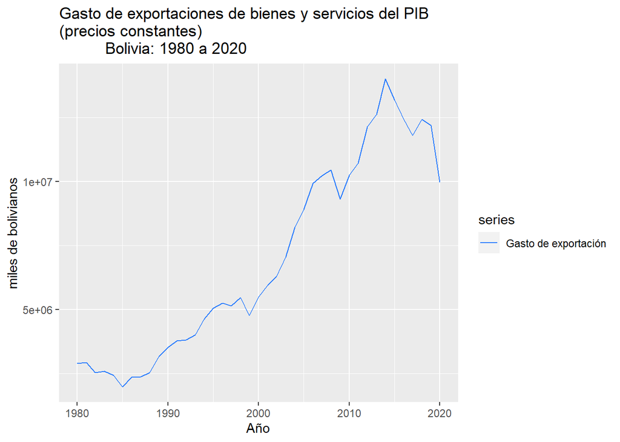

```r
url<-"https://raw.githubusercontent.com/bladimir-morales/series_de_tiempo/main/data/exportacion.txt"
exportacion<-read.table(url,head=T)
exportacion_serie<-ts(exportacion$exportacion ,start = c(1980),frequency = 1)

autoplot(exportacion_serie,series = "Gasto de exportación")+
  ggtitle("Gasto de exportaciones de bienes y servicios del PIB \n(precios constantes)
          Bolivia: 1980 a 2020 ")+
  xlab("Año")+ylab("miles de bolivianos")+
  scale_color_manual(values="#2B7DFF")
```

En el gráfico visualmente se puede observar que la serie de tiempo en estudio tendría tendencia aditiva creciente hasta 2014 y luego desde el 2015 una tendencia decreciente, como es una serie anual no presenta estacionalidad. Pero para determinar de mejor forma estos efectos se hará un análisis de gráficos de tendencia.

### 3.2.1 Tendencia

Para obtener la tendencia de la serie de tiempo, se aplicará una media móvil de orden 3.

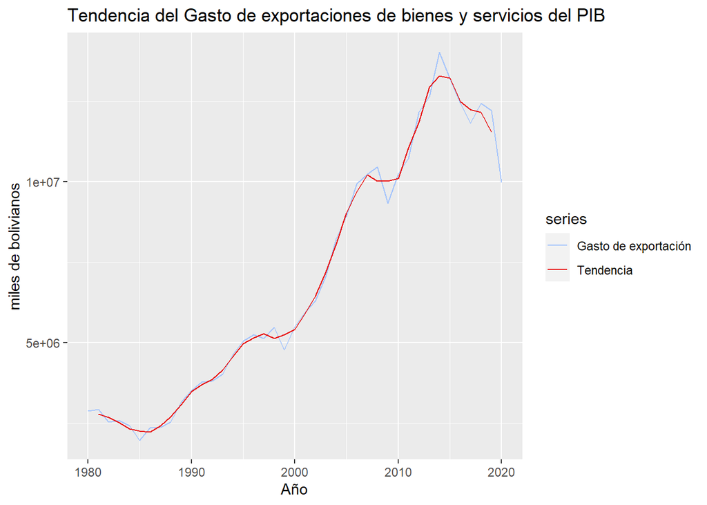

```r
ma_exportacion_serie<-ma(exportacion_serie,order = 3)

autoplot(exportacion_serie,series = "Gasto de exportación")+
  autolayer(ma_exportacion_serie,series="Tendencia")+
  ggtitle("Tendencia del Gasto de exportaciones de bienes y servicios del PIB")+
  xlab("Año")+ylab("miles de bolivianos")+
  scale_color_manual(values=c("#A4C4FC","#E80808"))
```

Con la media móvil de orden 3 se puede observar en el gráfico la tendencia aditiva de la serie de tiempo creciente hasta el 2014 y a partir del 2015 va descendiendo, según el economista Jose Gabriel Espinosa explica que las exportaciones bolivianas se concentraron tanto en ciertos productos y mercados, que aumentaron la vulnerabilidad de la economía a contextos com el que se vio con la caída de los precios de las materias primas.

Las exportaciones de hidrocarburos llegaron a mantener un crecimiento constante hasta 2013 reportando un valor de 6.624 millones de dólares, pero, después, declinaron hasta registrar un valor exportado de 3.972 millones de dólares en 2015 y se constituyó en el rubro más afectado por la caída de los precios internacionales.

Los minerales tampoco se quedaron atrás en el dudoso ranking de caídas. El valor de las exportaciones cayó en 2013 y 2014 por la caída del precio internacional de este rubro. Toda esta información se puede ver a mayor detalle en el reportaje del sitio web del periodico “Los Tiempos”[^6].

**Conclusión:**  
Se puede concluir entonces con un análisis visual que la serie en estudio del gasto de exportaciones de bienes y servicios del PIB de Bolivia cuenta con tendencia aditiva creciente hasta el 2014 y a partir del 2015 decreciente.

## 3.3 Datos de entrenamiento y test

Para efecto de obtener un modelo óptimo y lo más preciso posible, se dividirá la serie de tiempo en dos conjuntos:

- Conjunto de datos de entrenamiento:

Se tomará en cuenta los datos desde 1980 hasta 2017, contando con 38 observaciones.

- Conjunto de datos de test.

Se tomará en cuenta los datos desde el 2018 hasta 2020, contando con 3 observaciones.

En el siguiente gráfico se puede observar la serie de entrenamiento y de test.

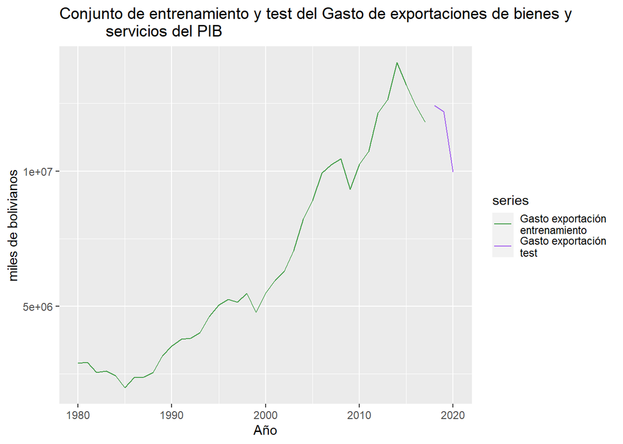

```r
exportacion_serie_ent<-ts(exportacion$exportacion,start = c(1980),end = c(2017), frequency=1)
exportacion_serie_test<-ts(exportacion$exportacion[39:41],start = c(2018), frequency=1)

autoplot(exportacion_serie_ent,series = "Gasto exportación \nentrenamiento")+
  autolayer(exportacion_serie_test,series="Gasto exportación \ntest")+
  ggtitle("Conjunto de entrenamiento y test del Gasto de exportaciones de bienes y
          servicios del PIB")+
  xlab("Año")+ylab("miles de bolivianos")+
  scale_color_manual(values=c("#469F4B","#A462EF"))
```

## 3.4 Estimación

Para efectos prácticos se estimará dos modelos para el conjunto de datos de entrenamiento en este caso un modelo de Holt y un Holt dos parámetros, tomando en cuenta que nuestra serie de tiempo como se pudo observar solo cuenta con tendencia, por tal motivo no seria correcto utilizar un modelo de Holt o Holt-Winters ya que cada uno corresponde cuando la serie de tiempo no tiene tendencia ni estacionalidad y el otro cuando tiene tendencia y estacionalidad, pero como se mencionó para efectos prácticos se utilizarán dos modelos.

### 3.4.1 Modelo 1

Para este modelo, se estimarán los datos con el método de Holt o también llamado suavizamiento exponencial simple, esto solo para efectos prácticos

La estimación se hará estimando un parámetro de suavizamiento $\alpha$. El software R cuenta con la función $HoltWinters()$ que encuentra los valores óptimos de los parámetros, en este caso para el $\alpha$.

```r
mod1_exportacion_serie_ent<-HoltWinters(exportacion_serie_ent,beta=F,gamma = F)
mod1_exportacion_serie_ent
```

```
## Holt-Winters exponential smoothing without trend and without seasonal component.
##
## Call:
## HoltWinters(x = exportacion_serie_ent, beta = F, gamma = F)
##
## Smoothing parameters:
##  alpha: 0.9999237
##  beta : FALSE
##  gamma: FALSE
##
## Coefficients:
##       [,1]
## a 11814116
```

### 3.4.2 Modelo 2

Para este segundo modelo, se estimarán los datos con el método de Holt dos parámetros o también llamado suavizamiento exponencial doble, esto debido a que la serie de tiempo cuenta con tendencia.

La estimación se hará estimando dos parámetros de suavizamiento $\alpha$ y $\beta$. El software R cuenta con la función $HoltWinters()$ que encuentra los valores óptimos de los parámetros, en este caso para el $\alpha$ y $\beta$.

```r
mod2_exportacion_serie_ent<-HoltWinters(exportacion_serie_ent,gamma = F)
mod2_exportacion_serie_ent
```

```
## Holt-Winters exponential smoothing with trend and without seasonal component.
##
## Call:
## HoltWinters(x = exportacion_serie_ent, gamma = F)
##
## Smoothing parameters:
##  alpha: 1
##  beta : 0.06989084
##  gamma: FALSE
##
## Coefficients:
##         [,1]
## a 11814068.3
## b   224626.1
```

## 3.5 MSE y MAPE

Se calculará el cuadrado medio del error MSE y el Porcentaje de error absoluto medio MAPE, para ambos modelos.

### 3.5.1 Cuadrado Medio del Error MSE

**Modelo 1. Modelo Holt (suavizamiento exponencial simple)**

```r
mse1<-mod1_exportacion_serie_ent$SSE/length(mod1_exportacion_serie_ent$x)
mse1
```

```
## [1] 393464530494
```

Para el modelo de Holt el cuadrado medio del error MSE es igual a 3.9346453^{11}

**Modelo 2. Modelo Holt dos parámetros (suavizamiento exponencial doble)**

```r
mse2<-mod2_exportacion_serie_ent$SSE/length(mod2_exportacion_serie_ent$x)
mse2
```

```
## [1] 353835803357
```

Para el modelo de Holt dos parámetros el cuadrado medio del error MSE es igual a 3.538358^{11}

### 3.5.2 Porcentaje de error absoluto medio MAPE

**Modelo 1. Modelo Holt (suavizamiento exponencial simple)**

```r
mape1<-mape(mod1_exportacion_serie_ent$x,mod1_exportacion_serie_ent$fitted[,1])
mape1
```

```
## [1] 8.024682
```

Para el modelo de Holt el porcentaje de error absoluto MAPE es igual a 8.0246822

**Modelo 2. Modelo Holt dos parámetros (suavizamiento exponencial doble)**

```r
mape2<-mape(mod2_exportacion_serie_ent$x,mod2_exportacion_serie_ent$fitted[,1])
mape2
```

```
## [1] 7.258785
```

Para el modelo de Holt dos parámetros el porcentaje de error absoluto MAPE es igual a 7.2587853

### 3.5.3 Decisión de modelo apropiado

Como se pudo observar el MSE y el MAPE del modelo Holt dos parámetros es menor al del modelo de Holt, por tal motivo nos quedamos con el modelo de suavizamiento exponencial doble.

## 3.6 Gráfico de la serie observada y ajustada

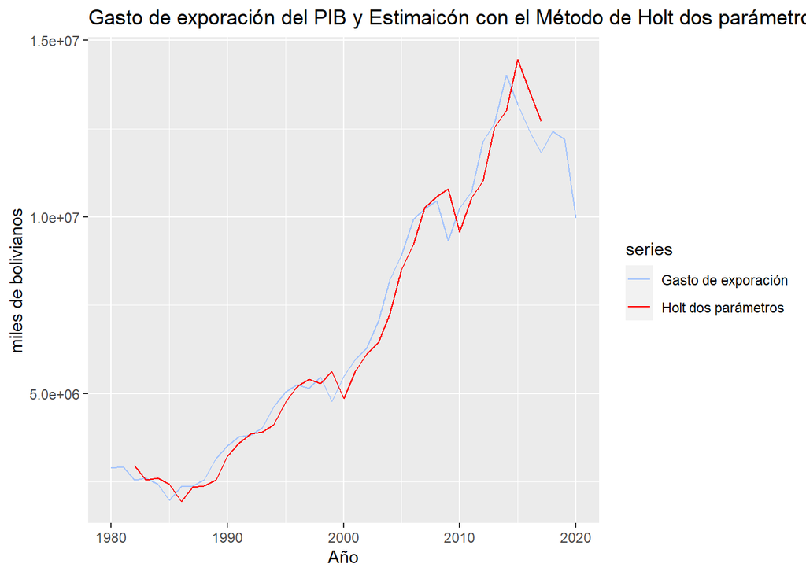

```r
autoplot(exportacion_serie,series = "Gasto de exporación")+
  autolayer(mod2_exportacion_serie_ent$fitted[,1],series="Holt dos parámetros")+
  ggtitle("Gasto de exporación del PIB y Estimaicón con el Método de Holt dos parámetros")+
  xlab("Año")+ylab("miles de bolivianos")+
  scale_color_manual(values=c("#A4C4FC","#FF0000"))
```

## 3.7 Predicción para datos de test

```r
pred_mod2_exportacion_serie_ent<-forecast(mod2_exportacion_serie_ent,3)
summary(pred_mod2_exportacion_serie_ent)
```

```
##
## Forecast method: HoltWinters
##
## Model Information:
## Holt-Winters exponential smoothing with trend and without seasonal component.
##
## Call:
## HoltWinters(x = exportacion_serie_ent, gamma = F)
##
## Smoothing parameters:
##  alpha: 1
##  beta : 0.06989084
##  gamma: FALSE
##
## Coefficients:
##         [,1]
## a 11814068.3
## b   224626.1
##
## Error measures:
##                    ME   RMSE      MAE      MPE     MAPE      MASE      ACF1
## Training set 74430.93 611141 471961.4 1.307369 7.662051 0.9097423 0.1455424
##
## Forecasts:
##      Point Forecast    Lo 80    Hi 80    Lo 95    Hi 95
## 2018       12038694 11250289 12827100 10832932 13244457
## 2019       12263321 11108726 13417915 10497520 14029121
## 2020       12487947 11024871 13951022 10250366 14725527
```

En el siguiente gráfico se puede observar de mejor manera los datos de predicción del conjunto de test, el conjunto de entrenamiento y el conjunto de test de la serie de tiempo en estudio.

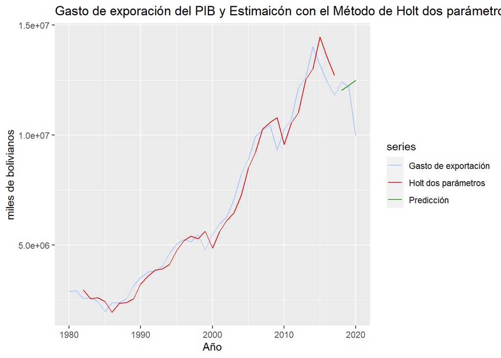

```r
autoplot(exportacion_serie,series = "Gasto de exportación")+
  autolayer(mod2_exportacion_serie_ent$fitted[,1],series="Holt dos parámetros")+
  autolayer(pred_mod2_exportacion_serie_ent$mean,series="Predicción")+
  ggtitle("Gasto de exporación del PIB y Estimaicón con el Método de Holt dos parámetros")+
  xlab("Año")+ylab("miles de bolivianos")+
  scale_color_manual(values=c("#A4C4FC","#E80808","#189B0D"))
```

## 3.8 MAPE para datos de test

Ahora se hallará el porcentaje de error absoluto medio MAPE de los datos de test con los datos de predicción a partir del modelo de Holt dos parámetros

```r
mape_test<-mape(exportacion_serie_test,pred_mod2_exportacion_serie_ent$mean)
mape_test
```

```
## [1] 9.647125
```

El MAPE para el conjunto de test es igual a 9.6471247, se puede ver que es mayor al MAPE del conjunto de entrenamiento (7.2587853). Esto puede ser respuesta a que el último año vale decir el 2020 tuvo una caida bastante fuerte las exportaciones que posiblemente sea por la pandemia de la Covid-19 que actualmente atraviesa nuestro planeta.

## 3.9 Predicción final

Finalmente se considerará todas las observaciones de la serie de tiempo del gasto en la exportación de bienes y servicios del producto interno bruto a precios constantes se Bolivia para poder predecir 5 años adelante, vale decir para el año 2021 al 2025. Hacer notar que al tratarse de una serie anual estimar bastantes años no serán muy confiables los últimos años estimados.

```r
modfin_exportacion_serie<-HoltWinters(exportacion_serie,gamma = F)
pred_modfin_exportacion_serie<-forecast(modfin_exportacion_serie,5)
```

También se puede obtener con el softare R un resumen del modelo aplicado en este caso Holt dos parámetros.

```r
summary(pred_modfin_exportacion_serie)
```

```
##
## Forecast method: HoltWinters
##
## Model Information:
## Holt-Winters exponential smoothing with trend and without seasonal component.
##
## Call:
## HoltWinters(x = exportacion_serie, gamma = F)
##
## Smoothing parameters:
##  alpha: 1
##  beta : 0.2269379
##  gamma: FALSE
##
## Coefficients:
##        [,1]
## a 9966050.5
## b -480464.8
##
## Error measures:
##                     ME     RMSE      MAE        MPE     MAPE      MASE
## Training set -58506.62 707117.8 511889.8 -0.1666655 7.732775 0.9194497
##                    ACF1
## Training set 0.05461775
##
## Forecasts:
##      Point Forecast   Lo 80    Hi 80   Lo 95    Hi 95
## 2021        9485586 8570679 10400492 8086357 10884814
## 2022        9005121 7556972 10453270 6790368 11219874
## 2023        8524656 6558324 10490988 5517411 11531902
## 2024        8044191 5547944 10540439 4226510 11861873
## 2025        7563727 4517791 10609662 2905370 12222083
```

Se puede observar que el MAPE bajo el modelo de Holt dos parámetros de todas las observaciones es mayor que el MAPE de los datos de entrenamiento con una diferencia de $0.4739897$ puntos porcentuales.

Por lo tanto se esperaría que para el año 2021 se tenga un gasto en la exportación de bienes y servicios del producto interno bruto a precios constantes en Bolivia de $9,485,586.00$ miles de bolivianos.

Para efectos visuales se presenta en el siguiente gráfico la serie original, la serie ajustada con el modelo de Holt dos parámetros y las predicciones con sus respectivos intervalos.

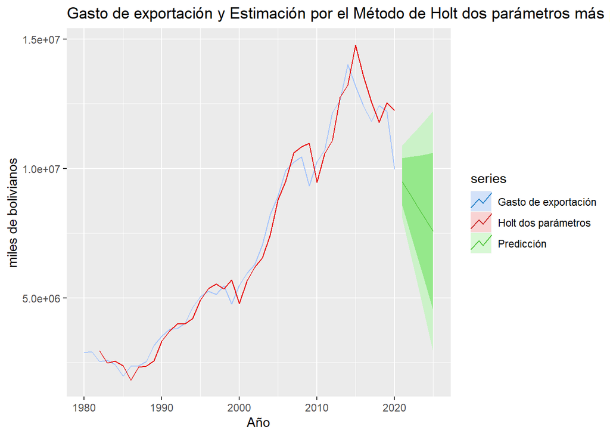

```r
autoplot(exportacion_serie,series = "Gasto de exportación")+
  autolayer(modfin_exportacion_serie$fitted[,1],series="Holt dos parámetros")+
  autolayer(pred_modfin_exportacion_serie,series="Predicción")+
  ggtitle("Gasto de exportación y Estimación por el Método de Holt dos parámetros más predicción")+
  xlab("Año")+ylab("miles de bolivianos")+
  scale_color_manual(values=c("#A4C4FC","#E80808","#189B0D"))
```

Para visualizar de mejor manera la predicción se tomará en cuenta los datos desde el año 2010.

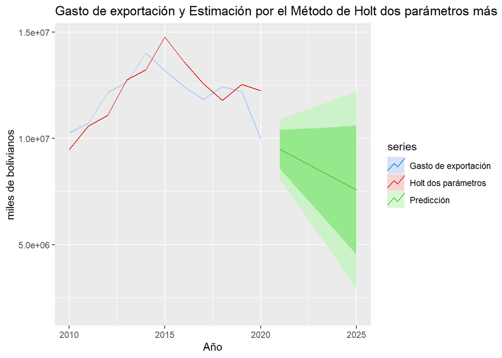

```r
autoplot(exportacion_serie,series = "Gasto de exportación")+
  autolayer(modfin_exportacion_serie$fitted[,1],series="Holt dos parámetros")+
  autolayer(pred_modfin_exportacion_serie,series="Predicción")+
  ggtitle("Gasto de exportación y Estimación por el Método de Holt dos parámetros más predicción")+
  xlab("Año")+ylab("miles de bolivianos")+
  xlim(2010,2025)+
  scale_color_manual(values=c("#A4C4FC","#E80808","#189B0D"))
```

## 3.10 Conclusiones

En esta sección se estudio la serie temporal anual del gasto en la exportación de bienes y servicios del producto interno bruto a precios constantes en Bolivia, desde el año 1980 hasta el 2020, teniendo en total 41 observaciones, se pudo determinar la existencia de tendencia creciente hasta el 2014 y a partir del 2015 decreciente.

Al ajustar la serie se propuso para efectos de práctica un modelo de Holt y un Holt dos parámetros (suavizamiento exponencial doble), al hallar el cuadrado medio del error MSE y el porcentaje de error absoluto medio MAPE se pudo determinar y decidir que el modelo óptimo para este estudio era el Holt dos parámetros asumiendo así que la serie aparte de contar con tendencia.

Una vez ajustado los datos con el modelo óptimo se hizo las predicciones a 5 años posteriores a los conocidos teniendo un gasto aproximado para la gestión 2021 de $9,485,586.00$ miles de bolivianos, mencionar también que los años posteriores de predicción cuentan con poca confiabilidad debido a que como se trata de una serie anual, se tiene que tomar muchos otros aspectos externos en cuenta como políticas públicas, acciones gubernamentales o tal vez crisis a nivel mundial, por tal motivo consideramos que la predicción para la gestión 2021 tendría mas probabilidad de confiabilidad.

# 4 Indice de consumo de agua potable ICAP

## 4.1 Descripción

### 4.1.1 Datos

El indice mensual de consumo de agua potable de Bolivia ICAP, es un indicador que nos permite conocer la evolución y comportamiento del consumo de agua potable de los sectores privado y público a nivel general con base en el año 1990, esto quiere decir que para esa gestión sera igual a 100 y luego el indice ira variando ya sea en incremento o decremento de acuerdo al consumo de agua potable del mes a tratarse.

### 4.1.2 Periodo de estudio

La serie de tiempo esta con periodicidad mensual, comprendidos desde enero de 1990 hasta julio de 2021, teniendo en total 379 observaciones.

### 4.1.3 Fuente de datos

La información del indice mensual de consumo de agua potable de Bolivia se puede encontrar en la página oficial del Instituto Nacional de Estadística (INE)[^7], sección de “Estadísticas Económicas” y subsección “Servicios básicos”. Específicamente se puede descargar los datos en formato establecido por la institución en excel del siguiente enlace: (https://nube.ine.gob.bo/index.php/s/M1H9axannIL7leg/download).

Los metadatos están disponibles en el Catálogo del Archivo Nacional de Datos (ANDA) del INE (http://anda4.ine.gob.bo/ANDA4_2/index.php/catalog/254).

Para fines prácticos se puso la variable en estudio en formato *.txt, el cual puede ser descargado del siguiente enlace (https://raw.githubusercontent.com/bladimir-morales/series_de_tiempo/main/data/agua.txt).

## 4.2 Gráfico

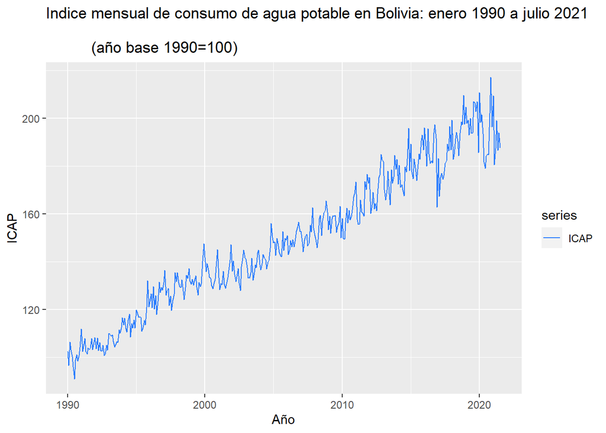

```r
url<-"https://raw.githubusercontent.com/bladimir-morales/series_de_tiempo/main/data/agua.txt"
agua<-read.table("./data/agua.txt",head=T)
agua_serie<-ts(agua$agua,start = c(1990,1),frequency = 12)

autoplot(agua_serie,series = "ICAP")+
  ggtitle("Indice mensual de consumo de agua potable en Bolivia: enero 1990 a julio 2021 \n
          (año base 1990=100)")+
  xlab("Año")+ylab("ICAP")+
  scale_color_manual(values="#2B7DFF")
```

En el gráfico visualmente se puede observar que la serie de tiempo en estudio tendría tendencia aditiva y efecto estacional. Pero para determinar de mejor forma estos efectos se hará un análisis de gráficos de tendencia y estacionalidad.

### 4.2.1 Tendencia

Para obtener la tendencia de la serie de tiempo, se aplicará una media móvil de orden 12 ya que las observaciones son mensuales.

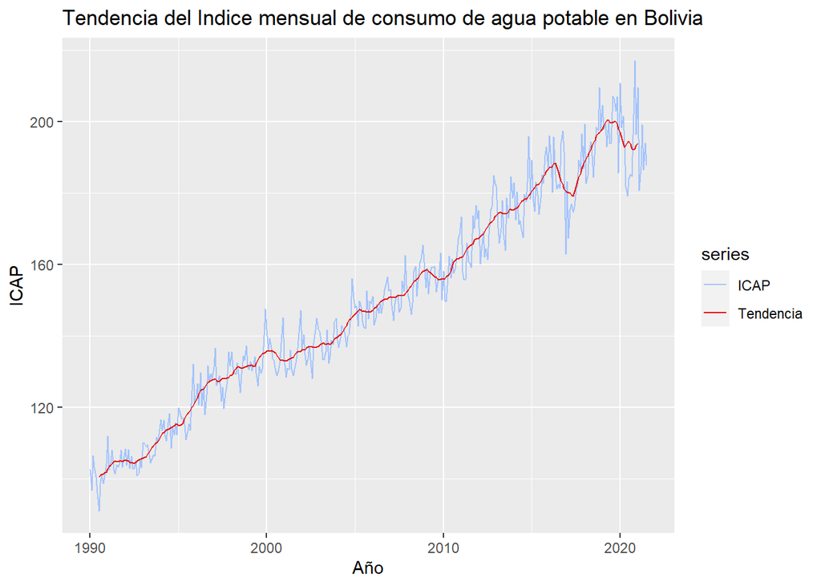

```r
ma_agua_serie<-ma(agua_serie,order = 12)

autoplot(agua_serie,series = "ICAP")+
  autolayer(ma_agua_serie,series="Tendencia")+
  ggtitle("Tendencia del Indice mensual de consumo de agua potable en Bolivia")+
  xlab("Año")+ylab("ICAP")+
  scale_color_manual(values=c("#A4C4FC","#E80808"))
```

Con la media móvil de orden 12 se puede observar en el gráfico la tendencia aditiva de la serie de tiempo, cabe mencionar que en diciembre del 2016 a aproximadamente junio del 2017 hay una rampa decreciente que puede explicarse por un fenómeno climático de sequía y falta de lluvias en Bolivia, lo cual derivó a un desabastecimiento de agua en ocho de los nueve departamentos del país y en 94 barrios del departamento de La Paz existió un racionamiento de agua, esto se detalla de mejor manera el reportaje de CNN en español en su portal web[^8].

### 4.2.2 Estacionalidad

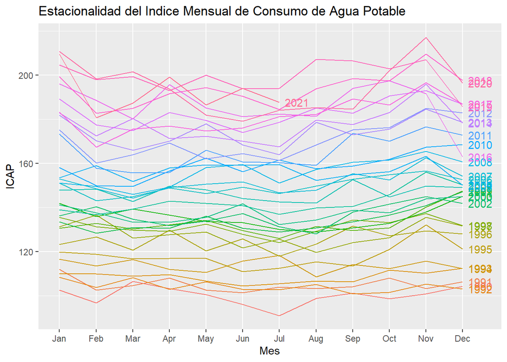

```r
ggseasonplot(agua_serie,main="Estacionalidad del Indice Mensual de Consumo de Agua Potable",
           year.labels = T,xlab="Mes",ylab="ICAP")
```

En este gráfico se puede observar que existe una tendencia creciente, ya que a medida que pasa cada año el consumo de agua potable va aumentando, por otro lado no se presente de manera clara el efecto estacional.

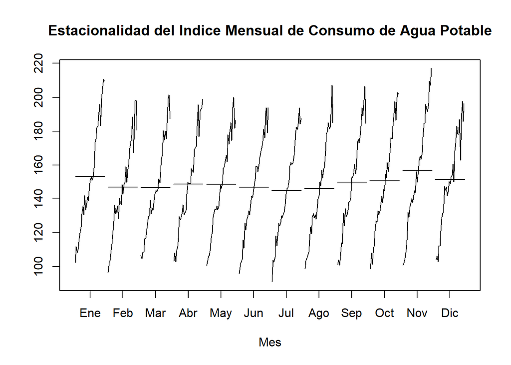

```r
monthplot(agua_serie,ylab="",main="Estacionalidad del Indice Mensual de Consumo de Agua Potable",
          labels = c("Ene","Feb","Mar","Abr","May","Jun","Jul","Ago","Sep","Oct","Nov","Dic"),
          xlab="Mes")
```

En este último gráfico se puede observar que podría existir un efecto estacional ya que en los meses de enero y noviembre asciende de manera muy leve el consumo de agua potable en Bolivia, pero en los demás meses se mantiene casi constantemente.

**Conclusión:**  
Se puede concluir entonces con un análisis visual que la serie en estudio del indice de consumo de agua potable en Bolivia tiene efecto de tendencia aditiva con una posible estacionalidad.

## 4.3 Datos de entrenamiento y test

Para efecto de obtener un modelo óptimo y lo más preciso posible, se dividirá la serie de tiempo en dos conjuntos:

- Conjunto de datos de entrenamiento:

Se tomará en cuenta los datos desde enero de 1990 hasta diciembre de 2019, contando con 360 observaciones.

- Conjunto de datos de test.

Se tomará en cuenta los datos desde enero de 2020 hasta julio de 2021, contando con 19 observaciones.

En el siguiente gráfico se puede observar la serie de entrenamiento y de test.

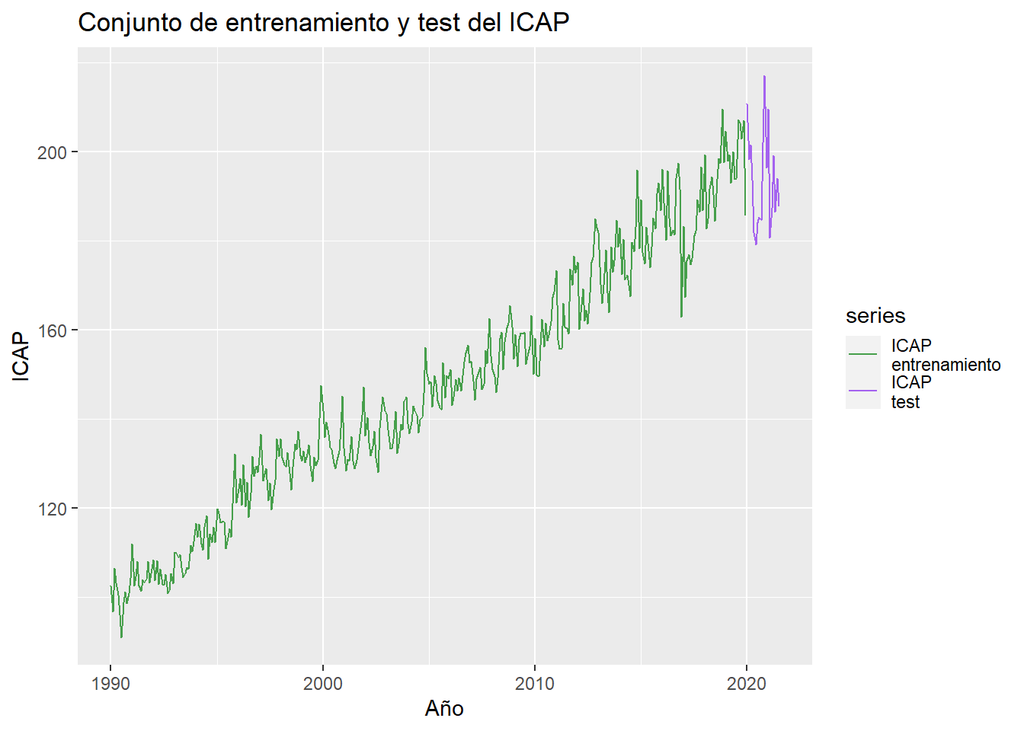

```r
agua_serie_ent<-ts(agua$agua,start = c(1990,1),end = c(2019,12), frequency=12)
agua_serie_test<-ts(agua$agua[361:379],start = c(2020,1), frequency=12)

autoplot(agua_serie_ent,series = "ICAP \nentrenamiento")+
  autolayer(agua_serie_test,series="ICAP \ntest")+
  ggtitle("Conjunto de entrenamiento y test del ICAP")+
  xlab("Año")+ylab("ICAP")+
  scale_color_manual(values=c("#469F4B","#A462EF"))
```

## 4.4 Estimación

Se estimaran dos modelos posibles para el conjunto de datos de entrenamiento, tomando en cuenta que nuestra serie de tiempo como se pudo observar visualmente tiene tendencia aditiva y posiblemente estacionalidad.

### 4.4.1 Modelo 1

Para este primer modelo, se estimarán los datos con el método de Holt dos parámetros o también llamado suavizamiento exponencial doble, esto debido a que la serie de tiempo cuenta con tendencia aditiva y posiblemente no tiene estacionalidad.

La estimación se hará estimando dos parámetros de suavizamiento $\alpha$ y $\beta$. El software R cuenta con la función $HoltWinters()$ que encuentra los valores óptimos de los parámetros, en este caso para el $\alpha$ y $\beta$.

```r
mod1_agua_serie_ent<-HoltWinters(agua_serie_ent,gamma = F)
mod1_agua_serie_ent
```

```
## Holt-Winters exponential smoothing with trend and without seasonal component.
##
## Call:
## HoltWinters(x = agua_serie_ent, gamma = F)
##
## Smoothing parameters:
##  alpha: 0.598481
##  beta : 0.07132043
##  gamma: FALSE
##
## Coefficients:
##          [,1]
## a 194.1702280
## b  -0.1270236
```

### 4.4.2 Modelo 2

Para este segundo modelo, se estimarán los datos con el método de Holt-Winters o también llamado suavizamiento exponencial triple, esto debido a que la serie de tiempo cuenta con tendencia aditiva y posiblemente estacionalidad.

La estimación se hará estimando tres parámetros de suavizamiento $\alpha$, $\beta$ y $\gamma$. El software R cuenta con la función $HoltWinters()$ que encuentra los valores óptimos de los parámetros, en este caso para el $\alpha$, $\beta$ y $\gamma$.

```r
mod2_agua_serie_ent<-HoltWinters(agua_serie_ent)
mod2_agua_serie_ent
```

```
## Holt-Winters exponential smoothing with trend and additive seasonal component.
##
## Call:
## HoltWinters(x = agua_serie_ent)
##
## Smoothing parameters:
##  alpha: 0.2753369
##  beta : 0.003570079
##  gamma: 0.3368634
##
## Coefficients:
##            [,1]
## a   199.0212813
## b     0.3259871
## s1    5.5621462
## s2   -6.1974265
## s3   -5.7383920
## s4   -4.0291071
## s5   -2.9745980
## s6   -6.9458011
## s7   -7.4355498
## s8   -0.4790144
## s9    1.9575468
## s10   1.2670500
## s11   7.5011989
## s12  -6.9785778
```

## 4.5 MSE y MAPE

Se calculará el cuadrado medio del error MSE y el Porcentaje de error absoluto medio MAPE, para ambos modelos.

### 4.5.1 Cuadrado Medio del Error MSE

**Modelo 1. Modelo Holt dos parámetros (suavizamiento exponencial doble)**

```r
mse1<-mod1_agua_serie_ent$SSE/length(mod1_agua_serie_ent$x)
mse1
```

```
## [1] 35.32866
```

Para el modelo de Holt dos parámetros el cuadrado medio del error MSE es igual a 35.3286596

**Modelo 2. Modelo Holt-Winters (suavizamiento exponencial triple)**

```r
mse2<-mod2_agua_serie_ent$SSE/length(mod2_agua_serie_ent$x)
mse2
```

```
## [1] 20.21008
```

Para el modelo de Holt-Winters el cuadrado medio del error MSE es igual a 20.2100801

### 4.5.2 Porcentaje de error absoluto medio MAPE

**Modelo 1. Modelo Holt dos parámetros**

```r
mape1<-mape(mod1_agua_serie_ent$x,mod1_agua_serie_ent$fitted[,1])
```

Para el modelo de Holt dos parámetros el porcentaje de error absoluto MAPE es igual a 3.1352602

**Modelo 2. Modelo Holt-Winters**

```r
mape2<-mape(mod2_agua_serie_ent$x,mod2_agua_serie_ent$fitted[,1])
```

Para el modelo de Holt-Winters el porcentaje de error absoluto MAPE es igual a 2.3140614

### 4.5.3 Decisión de modelo apropiado

Como se pudo observar el MSE y el MAPE del modelo Holt-Winters es menor al del modelo de Holt dos parámetros, por tal motivo se decide modelar la serie de tiempo con el modelo de suavizamiento exponencial triple.

## 4.6 Gráfico de la serie observada y ajustada

Para el siguiente gráfico se utilizará el modelo de Holt-Winters para ajustar la serie de tiempo del conjunto de entrenamiento.

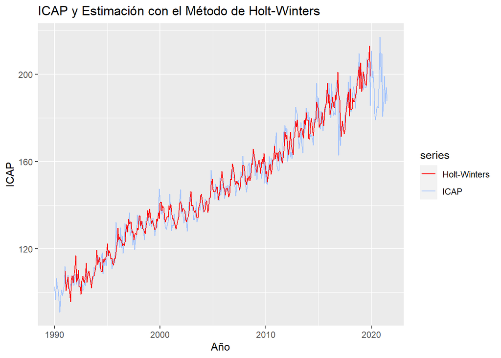

```r
autoplot(agua_serie,series = "ICAP")+
  autolayer(mod2_agua_serie_ent$fitted[,1],series="Holt-Winters")+
  ggtitle("ICAP y Estimación con el Método de Holt-Winters")+
  xlab("Año")+ylab("ICAP")+
  scale_color_manual(values=c("#FF0000","#A4C4FC"))
```

## 4.7 Predicción para datos de test

Con el modelo de Holt-Winters se predicirá los 19 datos restantes del conjunto de test a partir de los datos de entrenamiento. Con el software R se halla estos datos de predicción con sus respectivos intervalos.

```r
pred_mod2_agua_serie_ent<-forecast(mod2_agua_serie_ent,19)
summary(pred_mod2_agua_serie_ent)
```

```
##
## Forecast method: HoltWinters
##
## Model Information:
## Holt-Winters exponential smoothing with trend and additive seasonal component.
##
## Call:
## HoltWinters(x = agua_serie_ent)
##
## Smoothing parameters:
##  alpha: 0.2753369
##  beta : 0.003570079
##  gamma: 0.3368634
##
## Coefficients:
##            [,1]
## a   199.0212813
## b     0.3259871
## s1    5.5621462
## s2   -6.1974265
## s3   -5.7383920
## s4   -4.0291071
## s5   -2.9745980
## s6   -6.9458011
## s7   -7.4355498
## s8   -0.4790144
## s9    1.9575468
## s10   1.2670500
## s11   7.5011989
## s12  -6.9785778
##
## Error measures:
##                      ME     RMSE      MAE        MPE     MAPE      MASE
## Training set -0.2882895 4.572415 3.533868 -0.2783634 2.393857 0.6364364
##                    ACF1
## Training set 0.08294634
##
## Forecasts:
##          Point Forecast    Lo 80    Hi 80    Lo 95    Hi 95
## Jan 2020       204.9094 199.0529 210.7660 195.9526 213.8662
## Feb 2020       193.4758 187.3998 199.5518 184.1834 202.7683
## Mar 2020       194.2609 187.9715 200.5502 184.6422 203.8795
## Apr 2020       196.2961 189.7991 202.7932 186.3597 206.2325
## May 2020       197.6766 190.9769 204.3764 187.4302 207.9230
## Jun 2020       194.0314 187.1335 200.9293 183.4820 204.5808
## Jul 2020       193.8676 186.7759 200.9594 183.0217 204.7136
## Aug 2020       201.1502 193.8683 208.4320 190.0135 212.2868
## Sep 2020       203.9127 196.4444 211.3811 192.4909 215.3346
## Oct 2020       203.5482 195.8967 211.1997 191.8462 215.2502
## Nov 2020       210.1083 202.2766 217.9400 198.1308 222.0859
## Dec 2020       195.9545 187.9456 203.9635 183.7059 208.2032
## Jan 2021       208.8213 200.2292 217.4133 195.6808 221.9617
## Feb 2021       197.3877 188.6315 206.1439 183.9962 210.7791
## Mar 2021       198.1727 189.2543 207.0911 184.5332 211.8122
## Apr 2021       200.2080 191.1292 209.2867 186.3232 214.0927
## May 2021       201.5885 192.3511 210.8259 187.4611 215.7158
## Jun 2021       197.9432 188.5488 207.3377 183.5757 212.3108
## Jul 2021       197.7795 188.2296 207.3294 183.1742 212.3848
```

En el siguiente gráfico se puede observar de mejor manera los datos de predicción del conjunto de test, el conjunto de entrenamiento y el conjunto de test de la serie de tiempo en estudio.

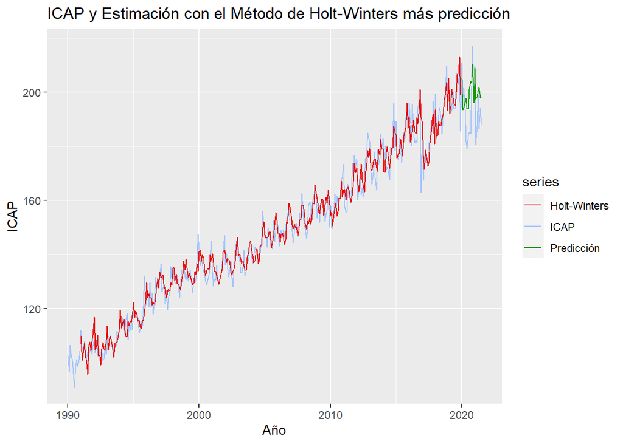

```r
autoplot(agua_serie,series = "ICAP")+
  autolayer(mod2_agua_serie_ent$fitted[,1],series="Holt-Winters")+
  autolayer(pred_mod2_agua_serie_ent$mean,series="Predicción")+
  ggtitle("ICAP y Estimación con el Método de Holt-Winters más predicción")+
  xlab("Año")+ylab("ICAP")+
  scale_color_manual(values=c("#E80808","#A4C4FC","#189B0D"))
```

## 4.8 MAPE para datos de test

Ahora se hallará el porcentaje de error absoluto medio MAPE de los datos de test con los datos de predicción a partir del modelo de Holt-Winters.

```r
mape_test<-mape(agua_serie_test,pred_mod2_agua_serie_ent$mean)
mape_test
```

```
## [1] 4.595676
```

El MAPE para el conjunto de test es igual a 4.5956761, se puede ver que es mayor al MAPE del conjunto de entrenamiento (2.3140614). Esto puede ser respuesta a que en estos últimos meses de la serie de tiempo existió mayor variabilidad en los datos como se pudo ver en el gráfico anterior.

## 4.9 Predicción final

Finalmente se considerará todas las observaciones de la serie de tiempo del indice del consumo de agua potable en Bolivia para poder predecir 5 meses adelante, vale decir del mes de agosto a diciembre del 2021.

```r
modfin_agua_serie<-HoltWinters(agua_serie)
modfin_agua_serie
```

```
## Holt-Winters exponential smoothing with trend and additive seasonal component.
##
## Call:
## HoltWinters(x = agua_serie)
##
## Smoothing parameters:
##  alpha: 0.2778392
##  beta : 0.003967102
##  gamma: 0.3283061
##
## Coefficients:
##            [,1]
## a   198.3470043
## b     0.2957990
## s1   -2.3767057
## s2   -0.1376436
## s3    4.0426552
## s4   11.5775091
## s5   -5.4361656
## s6    7.7426290
## s7   -8.8078355
## s8   -5.7028036
## s9   -3.3165770
## s10  -8.2275617
## s11  -8.1375603
## s12  -8.9261821
```

```r
pred_modfin_agua_serie<-forecast(modfin_agua_serie,5)
```

También se puede obtener con el softare R un resumen del modelo aplicado en este caso Holt-Winters.

```r
summary(pred_modfin_agua_serie)
```

```
##
## Forecast method: HoltWinters
##
## Model Information:
## Holt-Winters exponential smoothing with trend and additive seasonal component.
##
## Call:
## HoltWinters(x = agua_serie)
##
## Smoothing parameters:
##  alpha: 0.2778392
##  beta : 0.003967102
##  gamma: 0.3283061
##
## Coefficients:
##            [,1]
## a   198.3470043
## b     0.2957990
## s1   -2.3767057
## s2   -0.1376436
## s3    4.0426552
## s4   11.5775091
## s5   -5.4361656
## s6    7.7426290
## s7   -8.8078355
## s8   -5.7028036
## s9   -3.3165770
## s10  -8.2275617
## s11  -8.1375603
## s12  -8.9261821
##
## Error measures:
##                      ME     RMSE      MAE       MPE     MAPE      MASE
## Training set -0.3184188 4.909301 3.759127 -0.296645 2.482221 0.6535444
##                   ACF1
## Training set 0.1195884
##
## Forecasts:
##          Point Forecast    Lo 80    Hi 80    Lo 95    Hi 95
## Aug 2021       196.2661 189.9793 202.5529 186.6512 205.8810
## Sep 2021       198.8010 192.2741 205.3278 188.8190 208.7829
## Oct 2021       203.2771 196.5169 210.0372 192.9383 213.6158
## Nov 2021       211.1077 204.1203 218.0951 200.4214 221.7940
## Dec 2021       194.3898 187.1807 201.5990 183.3643 205.4153
```

Se puede observar que el MAPE bajo el modelo de Holt-Winters de todas las observaciones es mayor que el MAPE de los datos de entrenamiento con una diferencia de $0.16816$ puntos porcentuales.

Por lo tanto se esperaría que para el mes de agosto se tenga un indice de consumo de agua potable en Bolivia de $196.26$, teniendo como punto máximo de consumo en el mes de noviembre.

Para efectos visuales se presenta en el siguiente gráfico la serie original, la serie ajustada con el modelo de Holt-Winters y las predicciones con sus respectivos intervalos.

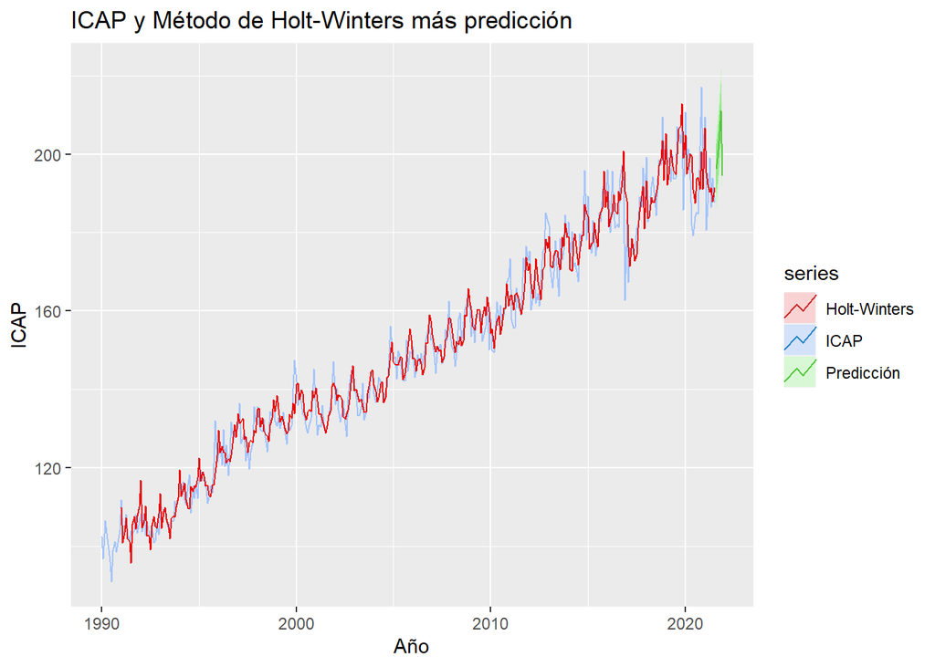

```r
autoplot(agua_serie,series = "ICAP")+
  autolayer(modfin_agua_serie$fitted[,1],series="Holt-Winters")+
  autolayer(pred_modfin_agua_serie,series="Predicción")+
  ggtitle("ICAP y Método de Holt-Winters más predicción")+
  xlab("Año")+ylab("ICAP")+
  scale_color_manual(values=c("#E80808","#A4C4FC","#189B0D"))
```

Para visualizar de mejor manera la predicción se tomará en cuenta los datos desde el año 2016.

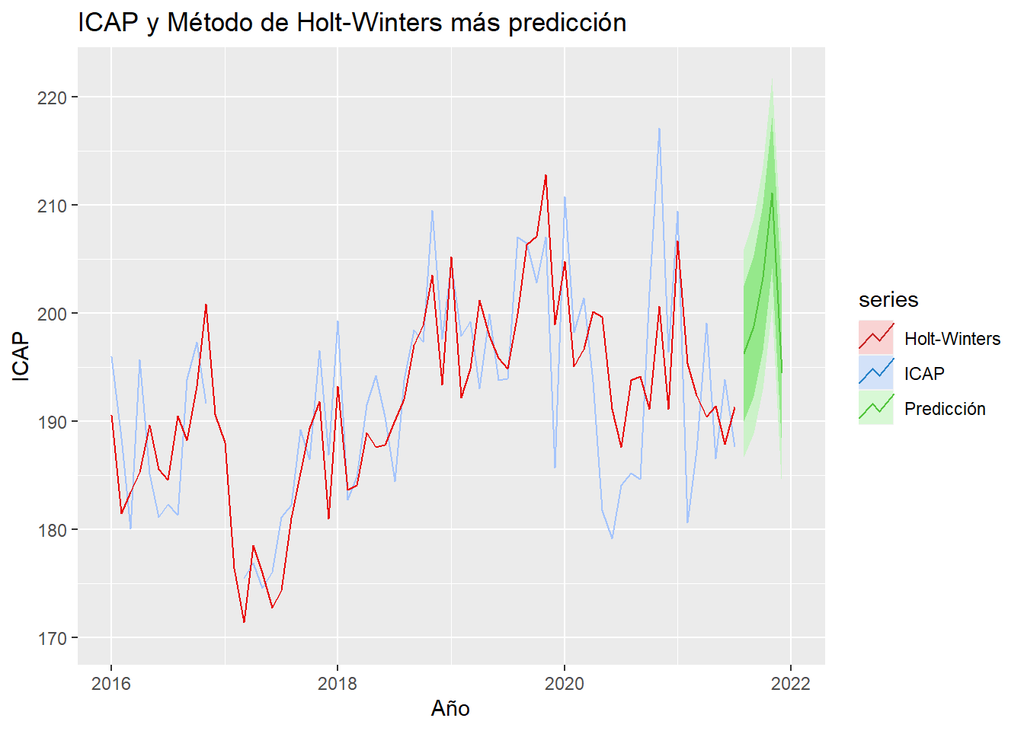

```r
autoplot(agua_serie,series = "ICAP")+
  autolayer(modfin_agua_serie$fitted[,1],series="Holt-Winters")+
  autolayer(pred_modfin_agua_serie,series="Predicción")+
  ggtitle("ICAP y Método de Holt-Winters más predicción")+
  xlab("Año")+ylab("ICAP")+
  xlim(2016,2022)+ylim(170,222)+
  scale_color_manual(values=c("#E80808","#A4C4FC","#189B0D"))
```

## 4.10 Conclusiones

En esta sección se estudio la serie temporal del indice de consumo de agua potable en Bolivia desde el periodo de enero de 1990 hasta julio del 2021, teniendo en total 379 observaciones con periodicidad mensual, se pudo determinar la existencia de tendencia aditiva con estacionalidad bajo un análisis de gráficos.

Al ajustar la serie se propuso un modelo de Holt dos parámetros y un modelo de Holt-Winters (suavizamiento exponencial triple), al hallar el cuadrado medio del error MSE y el porcentaje de error absoluto medio MAPE para los datos de entrenamiento se pudo determinar y decidir que el modelo óptimo para este estudio es el de Holt-Winters, asumiendo así que la serie aparte de contar con tendencia adtivia también cuenta con efecto estacional.

Una vez ajustado los datos con el modelo óptimo se hizo las predicciones a 5 meses posteriores a los conocidos teniendo un indice aproximado de consumo de agua para el mes de agosto de $196.26$ y observando que probablemente el mes de noviembre sea el que mayor indice presente en estos últimos cinco meses del presente año.

[^1]: https://es.wikipedia.org/wiki/Inflaci%C3%B3n
[^2]: www.bcb.gob.bo
[^3]: Caída del mercado de valores en la historia de la Bolsa en Estados Unidos, teniendo un alcance global y una larga duración de sus secuelas.
[^4]: https://www.deudaexterna.es/quien-invento-el-producto-interior-bruto-pib/
[^5]: www.ine.gob.bo
[^6]: https://www.lostiempos.com/actualidad/economia/20160803/decada-repunte-exportaciones-se-desploman
[^7]: www.ine.gob.bo
[^8]: https://cnnespanol.cnn.com/2016/11/21/declaran-emergencia-nacional-en-bolivia-por-sequia-y-falta-de-agua/